# Solutions to Exercises of Introduction to Statistical Learning, Chapter 4

Guillermo Martinez Dibene

23rd of April, 2021

# Exercise 10

In this exercise we will study the Weekly data set, which is part of the ISLR library. This data contains 1,089 weekly returns fro 21 years, from the beginning of 1990 to the end of 2010. We are looking to find a good predictive model.

The following matrix-plot produces scatter plots for each pair of variables, it adjusts a density estimation and calculates the correlations between pairs of variables. As expected, these correlation are near zero, the densities are centred at zero and they have low variance.

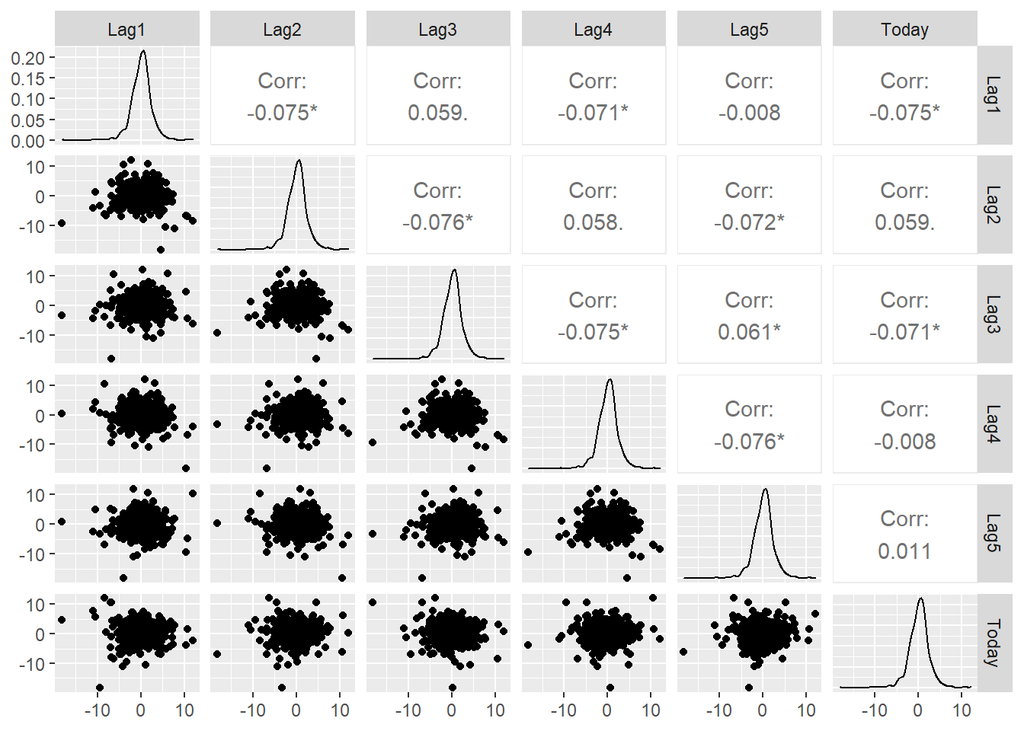

```r
ggpairs(Weekly, columns = c("Lag1", "Lag2", "Lag3", "Lag4", "Lag5", "Today"))
```

```r
logistic_full <- glm(Direction ~ . - Today - Year, data = data, family = binomial)
summary(logistic_full)
```

```
##
## Call:
## glm(formula = Direction ~ . - Today - Year, family = binomial,
##     data = data)
##
## Deviance Residuals:
##     Min       1Q   Median       3Q      Max
## -1.6949  -1.2565   0.9913   1.0849   1.4579
##
## Coefficients:
##             Estimate Std. Error z value Pr(>|z|)
## (Intercept)  0.26686    0.08593   3.106   0.0019 **
## Lag1        -0.04127    0.02641  -1.563   0.1181
## Lag2         0.05844    0.02686   2.175   0.0296 *
## Lag3        -0.01606    0.02666  -0.602   0.5469
## Lag4        -0.02779    0.02646  -1.050   0.2937
## Lag5        -0.01447    0.02638  -0.549   0.5833
## Volume      -0.02274    0.03690  -0.616   0.5377
## ---
## Signif. codes:  0 '***' 0.001 '**' 0.01 '*' 0.05 '.' 0.1 ' ' 1
##
## (Dispersion parameter for binomial family taken to be 1)
##
##     Null deviance: 1496.2  on 1088  degrees of freedom
## Residual deviance: 1486.4  on 1082  degrees of freedom
## AIC: 1500.4
##
## Number of Fisher Scoring iterations: 4
```

```r
data <- add_predictions(data, logistic_full)
data <- data %>%
    mutate(pred_Class = ifelse(pred > 0.5, "Up", "Down"))
cm_logistic <- data %>%
    group_by(Direction, pred_Class) %>%
    count() %>%
    pivot_wider(names_from = Direction, values_from = n, names_prefix = "actual_")
```

| Quantity | Value |
| --- | --- |
| Accuracy | $\dfrac{465 + 42}{1089} = 46.56\%$ |
| Sensitivity | $\dfrac{42}{19+42} = 68.85\%$ |
| False Positive Rate | $\dfrac{19}{19+465} = 3.9\%$ |

Now, the *Accuracy* of the model is simply the percentage of times the model *was* correct overall. The *Sensitivity* is the percentage of times the model correctly predicted an *increase in the market when the market actually increased*, while the *False Positive Rate* is simply the percentage of times the model *mistakenly predicted going up while the market went down*. It is important to always provide the confusion matrix because these and several other rates can be computed from it.

Notice that this model was evaluated using the data which we used to trained it. This already implies that the model will likely have a worse outcome if we were to test it.

## Other models

We are now going to study other possible models. In particular, we will consider KNN and Logistic with less parameters.

### Logistic regression with less predictors

We will use the past to predict the future. In other words, we will split the data using years before 2010 and 2010. In what follows, we train the models using the years 1990-2009 and we test using the year 2010.

```r
data <- as_tibble(Weekly)
data_train <- data %>%
    filter(
        Year < 2010
    )
data_test <- data %>%
    filter(
        Year == 2010
    )

model_logis <- glm(Direction ~ Lag2, data = data_train, family = binomial)
model_logis
```

```
##
## Call:  glm(formula = Direction ~ Lag2, family = binomial, data = data_train)
##
## Coefficients:
## (Intercept)         Lag2
##     0.20416      0.05188
##
## Degrees of Freedom: 1036 Total (i.e. Null);  1035 Residual
## Null Deviance:       1426
## Residual Deviance: 1422  AIC: 1426
```

```r
pred_logis <- data_test %>%
    add_predictions(model_logis, type = "response")
```

We will consider now a logistic regression model in which `Direction`is modeled only using `Lag2`. The confusion matrix is

```r
pred_logis <- pred_logis %>%
    mutate(
        pred_Class = ifelse(pred > 0.5, "Up", "Down"),
        pred_Class = as_factor(pred_Class)
    )
cm_logis <- pred_logis %>%
    group_by(Direction, pred_Class) %>%
    count() %>%
    pivot_wider(names_from = Direction, values_from = n, names_prefix = "actual_", values_fill = 0)
cm_logis
```

```
## # A tibble: 2 x 3
## # Groups:   pred_Class [2]
##   pred_Class actual_Down actual_Up
##   <fct>            <int>     <int>
## 1 Up                  17        32
## 2 Down                 3         0
```

With this table, we can calculate

| Quantity | Value |
| --- | --- |
| Accuracy | $\dfrac{35}{52} = 67.30\%$ |
| Sensitivity | $100\%$ |
| False Positive Rate | $\dfrac{17}{17+3} = 85\%$ |

Let us consider now a model with `Lag2` and `Lag5` as predictors.

```r
model_logis_25 <- glm(Direction ~ Lag2 + Lag5, data = data_train, family = binomial)
summary(model_logis_25)
```

```
##
## Call:
## glm(formula = Direction ~ Lag2 + Lag5, family = binomial, data = data_train)
##
## Deviance Residuals:
##    Min      1Q  Median      3Q     Max
## -1.630  -1.260   1.021   1.090   1.350
##
## Coefficients:
##             Estimate Std. Error z value Pr(>|z|)
## (Intercept)  0.20651    0.06280   3.288  0.00101 **
## Lag2         0.05097    0.02697   1.890  0.05877 .
## Lag5        -0.01532    0.02678  -0.572  0.56733
## ---
## Signif. codes:  0 '***' 0.001 '**' 0.01 '*' 0.05 '.' 0.1 ' ' 1
##
## (Dispersion parameter for binomial family taken to be 1)
##
##     Null deviance: 1426.1  on 1036  degrees of freedom
## Residual deviance: 1422.0  on 1034  degrees of freedom
## AIC: 1428
##
## Number of Fisher Scoring iterations: 4
```

```r
pred_logis_25 <- data_test %>%
    add_predictions(model_logis_25, type = "response")
pred_logis_25 <- pred_logis_25 %>%
    mutate(
        pred_Class = ifelse(pred > 0.5, "Up", "Down"),
        pred_Class = as_factor(pred_Class)
    )
cm_logis_25 <- pred_logis_25 %>%
    group_by(Direction, pred_Class) %>%
    count() %>%
    pivot_wider(names_from = Direction, values_from = n, names_prefix = "actual_", values_fill = 0)
```

Let us now move away from logistic regression and let us consider a linear discriminant model. In theory, this should perform the similar to logistic regression, improving when the hypothesis of LDA are met by the data.

#### Linear Discriminant Analysis

```r
model_lda <- lda(Direction ~ Lag2, data_train)
model_lda
```

```
## Call:
## lda(Direction ~ Lag2, data = data_train)
##
## Prior probabilities of groups:
##      Down        Up
## 0.4474446 0.5525554
##
## Group means:
##             Lag2
## Down -0.01205819
## Up    0.27317277
##
## Coefficients of linear discriminants:
##            LD1
## Lag2 0.4251927
```

```r
pred_lda <-predict(newdata = data_test, object = model_lda)
model_lda <- data_test %>%
    mutate(pred_Class = pred_lda$class)
cm_lda <- model_lda %>%
    group_by(Direction, pred_Class) %>%
    count() %>%
    pivot_wider(names_from = Direction, values_from = n, names_prefix = "actual_", values_fill = 0)
cm_lda
```

```
## # A tibble: 2 x 3
## # Groups:   pred_Class [2]
##   pred_Class actual_Down actual_Up
##   <fct>            <int>     <int>
## 1 Down                 3         0
## 2 Up                  17        32
```

This confusion table is again exactly the same as the previous two models, this is expected, LDA behaves similarly to logistic regression.

### Quadratic Discriminant Analysis

```r
model_qda <- qda(Direction ~ Lag2, data_train)
model_qda
```

```
## Call:
## qda(Direction ~ Lag2, data = data_train)
##
## Prior probabilities of groups:
##      Down        Up
## 0.4474446 0.5525554
##
## Group means:
##             Lag2
## Down -0.01205819
## Up    0.27317277
```

```r
pred_qda <-predict(newdata = data_test, object = model_qda)
model_qda <- data_test %>%
    mutate(pred_Class = pred_qda$class)
cm_qda <- model_qda %>%
    group_by(Direction, pred_Class) %>%
    count() %>%
    pivot_wider(names_from = Direction, values_from = n, names_prefix = "actual_", values_fill = 0)
```

Having the model saved, we can now print its confusion matrix

```r
cm_qda
```

```
## # A tibble: 1 x 3
## # Groups:   pred_Class [1]
##   pred_Class actual_Down actual_Up
##   <fct>            <int>     <int>
## 1 Up                  20        32
```

Interestingly, QDA only predicted positive direction for 2010, obtaining

[output not shown]

Let us also consider a QDA model in which we use all previous days

```r
model_qda_full <- qda(Direction ~ . - Year - Volume - Today, data_train)
model_qda_full
```

```
## Call:
## qda(Direction ~ . - Year - Volume - Today, data = data_train)
##
## Prior probabilities of groups:
##      Down        Up
## 0.4474446 0.5525554
##
## Group means:
##            Lag1        Lag2      Lag3       Lag4       Lag5
## Down 0.26518750 -0.01205819 0.1825905 0.20216595 0.19393319
## Up   0.04972426  0.27317277 0.1093037 0.09298429 0.09125305
```

```r
pred_qda_full <-predict(newdata = data_test, object = model_qda_full)
model_qda_full <- data_test %>%
    mutate(pred_Class = pred_qda_full$class)
cm_qda_full <- model_qda_full %>%
    group_by(Direction, pred_Class) %>%
    count() %>%
    pivot_wider(names_from = Direction, values_from = n, names_prefix = "actual_", values_fill = 0)
```

The confusion matrix is

```r
cm_qda_full
```

```
## # A tibble: 2 x 3
## # Groups:   pred_Class [2]
##   pred_Class actual_Down actual_Up
##   <fct>            <int>     <int>
## 1 Down                 7         8
## 2 Up                  13        24
```

Things are again different.

| Quantity | Value |
| --- | --- |
| Accuracy | $\dfrac{31}{52} = 59.61\%$ |
| Sensitivity | $\dfrac{24}{32} = 75\%$ |
| False Positive Rate | $\dfrac{13}{20} = 65\%$ |

### K Nearest Neighbours

We now move to try a KNN model for the data.

```r
library(class)
train_X <- data_train %>%
    dplyr::select(Lag2)
test_X <- data_test %>%
    dplyr::select(Lag2)
```

```r
pred_knn_1 <- knn(train_X, test_X, data_train$Direction, k = 1)
table(pred_knn_1, data_test$Direction)
```

```
##
## pred_knn_1 Down Up
##       Down    8 15
##       Up     12 17
```

This confusion matrix

| Quantity | Value |
| --- | --- |
| Accuracy | $\dfrac{25}{52} = 48\%$ |
| Sensitivity | $\dfrac{17}{32} = 53.13\%$ |
| False Positivity Rate | $\dfrac{12}{20} = 60\%$ |

We repeat with different parameters for k,

```r
pred_knn_3 <- knn(train_X, test_X, data_train$Direction, k = 3)
pred_knn_5 <- knn(train_X, test_X, data_train$Direction, k = 5)
pred_knn_7 <- knn(train_X, test_X, data_train$Direction, k = 7)
table(pred_knn_3, data_test$Direction)
```

```
##
## pred_knn_3 Down Up
##       Down    8 10
##       Up     12 22
```

```r
table(pred_knn_5, data_test$Direction)
```

```
##
## pred_knn_5 Down Up
##       Down    8 12
##       Up     12 20
```

```r
table(pred_knn_7, data_test$Direction)
```

```
##
## pred_knn_7 Down Up
##       Down    8 11
##       Up     12 21
```

None of these models beat a simple “always beat up” strategy.

# Exercise 11

This exercise will try to model if miles per gallon can be predicted as high or low given other characteristics and information for the car. This uses the Auto data set from the ISLR library.

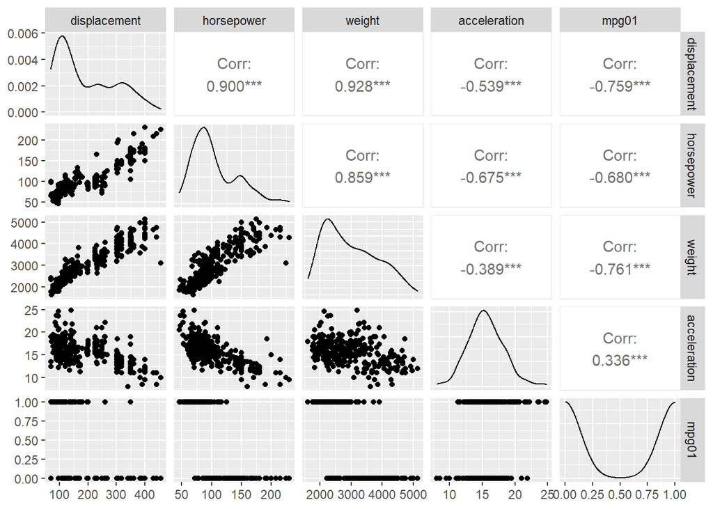

```r
auto_data <- as_tibble(Auto)
auto_data <- auto_data %>%
    mutate(
        mpg01 = ifelse(mpg > median(mpg), 1, 0),
        id = 1:nrow(auto_data)
    )

auto_train <- auto_data %>%
    slice_sample(prop = .8)
auto_test  <- anti_join(auto_data, auto_train, by = "id")

ggpairs(auto_train,columns = c("displacement", "horsepower", "weight", "acceleration", "mpg01"))
```

The previous graph shows a very strong correlation between `displacement`, `horsepower`, `weight` and `acceleration`. It seems sensible to use only the pair that has less correlation. This pair is `weight` and `acceleration`.

```r
mpg_logis <- glm(mpg01 ~ weight + acceleration, data = auto_train, family = binomial)
summary(mpg_logis)
```

```
##
## Call:
## glm(formula = mpg01 ~ weight + acceleration, family = binomial,
##     data = auto_train)
##
## Deviance Residuals:
##      Min        1Q    Median        3Q       Max
## -2.53307  -0.26126  -0.00655   0.39682   2.90330
##
## Coefficients:
##                Estimate Std. Error z value Pr(>|z|)
## (Intercept)   8.8717199  1.6377648   5.417 6.06e-08 ***
## weight       -0.0043284  0.0005118  -8.457  < 2e-16 ***
## acceleration  0.2189300  0.0832333   2.630  0.00853 **
## ---
## Signif. codes:  0 '***' 0.001 '**' 0.01 '*' 0.05 '.' 0.1 ' ' 1
##
## (Dispersion parameter for binomial family taken to be 1)
##
##     Null deviance: 433.91  on 312  degrees of freedom
## Residual deviance: 172.71  on 310  degrees of freedom
## AIC: 178.71
##
## Number of Fisher Scoring iterations: 7
```

It seems that all the coefficients are “statistically significant.” It is important to notice that `weight` has very small coefficient. However, weight is in pounds (lb.) and so, the weight of every car is several thousands.

```r
pred_logis <- add_predictions(auto_test, mpg_logis, type = "response")
pred_logis <- pred_logis %>%
    mutate(
        pred_Class = ifelse(pred > 0.5, 1, 0)
    )
cm_logis <- pred_logis %>%
    group_by(mpg01, pred_Class) %>%
    count() %>%
    pivot_wider(
        names_from = pred_Class,
        values_from = n,
        names_prefix = "predicted_",
        values_fill = 0
    )
```

The confusion matrix for this model is

```r
cm_logis
```

```
## # A tibble: 2 x 3
## # Groups:   mpg01 [2]
##   mpg01 predicted_0 predicted_1
##   <dbl>       <int>       <int>
## 1     0          33           6
## 2     1           4          36
```

Three important quantities and their values from this model

[output not shown]

Notice that the predicted variable is spit 50-50 among the two classes (by definition of the median). This model is much better than random guessing, which would yield an accuracy, sensitivity and false positive rate, in average, of 50%.

## LDA for the Auto dataset

```r
mpg_lda <- lda(mpg01 ~ weight + acceleration, data = auto_train)
mpg_lda
```

```
## Call:
## lda(mpg01 ~ weight + acceleration, data = auto_train)
##
## Prior probabilities of groups:
##         0         1
## 0.5015974 0.4984026
##
## Group means:
##     weight acceleration
## 0 3625.917     14.62102
## 1 2342.115     16.47564
##
## Coefficients of linear discriminants:
##                       LD1
## weight       -0.001779431
## acceleration  0.034618328
```

```r
pred_mpg_lda <- predict(mpg_lda, auto_test)
cm_mpg_lda <- auto_test %>%
    mutate(
        pred_Class = pred_mpg_lda$class
    ) %>%
    group_by(mpg01, pred_Class) %>%
    count() %>%
    pivot_wider(
        names_from = mpg01,
        values_from = n,
        names_prefix = "actual_",
        values_fill = 0
    )
```

The confusion matrix yields the following information, it is readily seen to perform substantially worse than logistic regression.

[output not shown]

## QDA for the auto dataset

```r
mpg_qda <- qda(mpg01 ~ weight + acceleration, data = auto_train)
mpg_qda
```

```
## Call:
## qda(mpg01 ~ weight + acceleration, data = auto_train)
##
## Prior probabilities of groups:
##         0         1
## 0.5015974 0.4984026
##
## Group means:
##     weight acceleration
## 0 3625.917     14.62102
## 1 2342.115     16.47564
```

```r
pred_mpg_qda <- predict(mpg_qda, auto_test)
cm_mpg_qda <- auto_test %>%
    mutate(
        pred_Class = pred_mpg_qda$class
    ) %>%
    group_by(mpg01, pred_Class) %>%
    count() %>%
    pivot_wider(
        names_from = mpg01,
        values_from = n,
        names_prefix = "actual_",
        values_fill = 0
    )
```

The three values we have been obtaining are

[output not shown]

## KNN with k = 1, 3, 4, 5, 7, 9

```r
library(class)
std_scaler <- function(data, mean, sd) {
    (data - mean) / sd
}
mu <- vector(mode = "double", length = 2)
sd <- vector(mode = "double", length = 2)
mu[1] = mean(auto_train$weight)
mu[2] = mean(auto_train$acceleration)
sd[1] = sd(auto_train$weight)
sd[2] = sd(auto_train$acceleration)

train_X_mpg <- tibble(
    std_weight = std_scaler(auto_train$weight, mu[1], sd[1]),
    std_acceleration = std_scaler(auto_train$acceleration, mu[2], sd[2])
)

test_X_mpg  <- tibble(
    std_weight = std_scaler(auto_test$weight, mu[1], sd[1]),
    std_acceleration = std_scaler(auto_test$acceleration, mu[2], sd[2])
)

train_y_mpg <- auto_train$mpg01

mpg_knn1 <- knn(train_X_mpg, test_X_mpg, train_y_mpg, 1)
mpg_knn3 <- knn(train_X_mpg, test_X_mpg, train_y_mpg, 3)
mpg_knn4 <- knn(train_X_mpg, test_X_mpg, train_y_mpg, 4)
mpg_knn5 <- knn(train_X_mpg, test_X_mpg, train_y_mpg, 5)
mpg_knn7 <- knn(train_X_mpg, test_X_mpg, train_y_mpg, 7)
mpg_knn9 <- knn(train_X_mpg, test_X_mpg, train_y_mpg, 9)
```

```
##
## mpg_knn1  0  1
##        0 31  6
##        1  8 34
```

```
##
## mpg_knn3  0  1
##        0 33  3
##        1  6 37
```

```
##
## mpg_knn4  0  1
##        0 31  3
##        1  8 37
```

```
##
## mpg_knn5  0  1
##        0 30  3
##        1  9 37
```

```
##
## mpg_knn7  0  1
##        0 33  4
##        1  6 36
```

```
##
## mpg_knn9  0  1
##        0 35  5
##        1  4 35
```

It becomes clear that increasing k from 1 to 3 increases the three quantities we have been studying but increasing it further seems to provide no further improvements. Also notice that this data has been standarised as to have mean zero and unit variance. The important values when we consider three neighbours ($k = 3$)

| Quantity | Value |
| --- | --- |
| Accuracy | $\dfrac{70}{79} = 88.6\%$ |
| Sensitivity | $\frac{37}{40} = 92.5\%$ |
| False Positive Rate | $\dfrac{6}{39} = 15.38\%$ |

### Conclusion for exercise 11

The best model we found was to use a standard scaler for the auto data, predicting high or low miles per gallon using weight and acceleration only. Our predictor is based on using KNN with k = 3.